# Activity

Marius Nick

15 decembrie 2015

## Introduction

Personal activity monitoring devices allow for the collection of large amounts of data about personal movement and physical activity. These measurements can be used to improve a person’s health and to find behaviour patterns.

In this assignment I’ll analyse data from a personal activity monitoring device. This device collects data at 5 minute intervals throughout the day. The data consists of two months of data from an anonymous individual collected during the months of October and November, 2012 and include the number of steps taken in 5 minute intervals each day.

## Load Data and preprocesing

```r
library(lubridate)
library(stringr)
setwd("~/R/Reproducible Research_1")
activity<-read.csv("activity.csv", sep=",")
summary(activity)
```

```
##      steps                date          interval
##  Min.   :  0.00   2012-10-01:  288   Min.   :   0.0
##  1st Qu.:  0.00   2012-10-02:  288   1st Qu.: 588.8
##  Median :  0.00   2012-10-03:  288   Median :1177.5
##  Mean   : 37.38   2012-10-04:  288   Mean   :1177.5
##  3rd Qu.: 12.00   2012-10-05:  288   3rd Qu.:1766.2
##  Max.   :806.00   2012-10-06:  288   Max.   :2355.0
##  NA's   :2304     (Other)   :15840
```

```r
#single days
date<-unique(activity$date)
#
```

## Calculate the total number of steps taken per day

```r
i<-rep(0,length(date))
stepsdays<-rep(0,length(date))
#total steps per day
for(i in 1:length(date)){stepsdays[i]<-sum(activity[activity$date==date[i],]$steps,na.rm = TRUE)}
```

## Mean and median of steps of days

Mean

```r
mean(stepsdays)
```

```
## [1] 9354.23
```

Median

```r
median(stepsdays)
```

```
## [1] 10395
```

## Histogram of the total number of steps taken each day

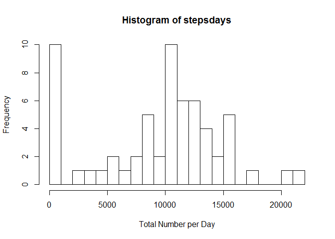

## Average daily activity pattern

```r
time<-(strptime(str_pad(as.character(activity[,3]),4,side="left",pad="0"),"%H%M"))
#dattee days in activity as format time
dattee<-strptime(as.character.Date(activity[,2]),"%Y-%m-%d")
year(time)<-year(dattee)
day(time)<-day(dattee)
month(time)<-month(dattee)
datte<-strptime(as.character.Date(date),"%Y-%m-%d")
```

## Average daily activity pattern

Now we create a profile of the activity in an “average” day.

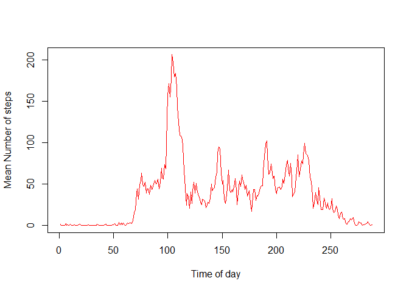

```r
# average number of steps taken, averaged across all days
interval<-unique(activity$interval)
 j<-0
 intervalmean<-rep(0,length(interval))
for( j in 1:length(interval)){intervalmean[j]<-mean(activity[activity$interval==interval[j],]$steps,na.rm=TRUE)}
#plot average
plot(intervalmean,type="l", col="red",xlab = "Time of day", ylab="Mean Number of steps")
```

# Maximum step

```r
max(intervalmean)
```

```
## [1] 206.1698
```

```r
for (i in 1:length(interval)) {if ( max(intervalmean)==intervalmean[i]) print(interval[i]) }
```

```
## [1] 835
```

The maximum average number of steps is 206.20 occurs at 835.

# Number of Na.s

There are a number of rows with NA values in the data. These missing data may introduce bias in summaries or calculations. First we find the total number of rows which contain missing data. From the summary that I printed after loading the data at the start, I know that missing entries only occur in the steps column.

```r
length(activity[is.na(activity$steps)==TRUE,]$steps)
```

```
## [1] 2304
```

```r
activity1<-activity
```

## Imputing missing values

```r
interval<-unique(activity$interval)
activity1<-activity

intervalmean<-as.data.frame(cbind(intervalmean,interval))
for(i in 1:length(activity1$steps))
    {if(is.na(activity1$steps[i]))
      {activity1$steps[i]<-intervalmean[intervalmean$interval==activity1$interval[i],]$intervalmean        }
    }

stepsdays1<-rep(0,length((date)))
for(i in 1:length(date)){stepsdays1[i]<-sum(activity1[activity1$date==date[i],]$steps)}
```

## Mean, median hitogram of steps of days whitout missing

```r
summary((stepsdays1))
```

```
##    Min. 1st Qu.  Median    Mean 3rd Qu.    Max.
##      41    9819   10770   10770   12810   21190
```

```r
mean(stepsdays1)
```

```
## [1] 10766.19
```

```r
median(stepsdays1)
```

```
## [1] 10766.19
```

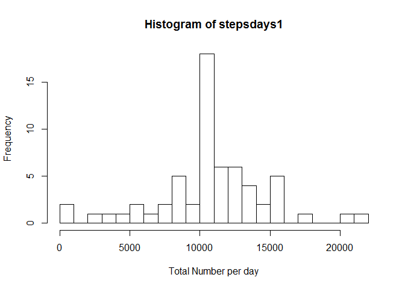

```r
hist(stepsdays1,n=20, xlab = "Total Number per day")
```

The mean total number of steps for the corrected dataset is 10767 steps, and the median is 10767 steps. Correcting the data we have a effect(small).

## Activity patterns in weekdays and weekends

```r
wdat<-weekdays(datte)
# Set my locale to en_US so that the weekdays() function outputs names of days in English.
Sys.setlocale(category = "LC_ALL", locale = "English_United States.1252")
```

```
## [1] "LC_COLLATE=English_United States.1252;LC_CTYPE=English_United States.1252;LC_MONETARY=English_United States.1252;LC_NUMERIC=C;LC_TIME=English_United States.1252"
```

```r
activity[,4]<-weekdays(strptime(as.character.Date(activity[,2]),"%Y-%m-%d"))
act_weekday<-activity[!(activity[,4]%in% c("Sunday","Saturday")),]
act_weekend<-activity[(activity[,4]%in% c("Sunday","Saturday")),]
 in_mean_weekend<-rep(0,length(interval))
for( j in 1:length(interval)){in_mean_weekend[j]<-mean(act_weekend[act_weekend$interval==interval[j],]$steps,na.rm=TRUE)}
 in_mean_weekday<-rep(0,length(interval))
for( j in 1:length(interval)){in_mean_weekday[j]<-mean(act_weekday[act_weekday$interval==interval[j],]$steps,na.rm=TRUE)}
```

We plot the time series for mean number of steps, separating weekdays (top panel, red) from weekends (bottom panel, blue).

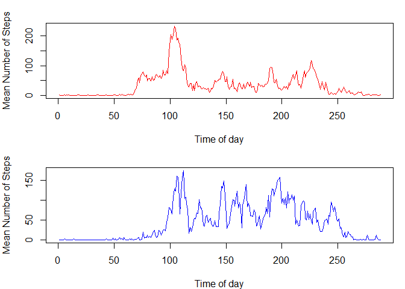

```r
par(mfrow=c(2,1),mar=c(4,4,2,1))
plot(in_mean_weekday,type="l", col="red", xlab = "Time of day", ylab = "Mean Number of Steps")
plot(in_mean_weekend,type="l", col="blue",xlab = "Time of day", ylab = "Mean Number of Steps")
```